# Project2

YuMei, Anthony & Nitin

March 31, 2018

Github repository https://github.com/tbitxyz/SMU-DDS-Machine-Churning-Project-2 —

## – Executive Summary –

The analysis uses the casestudy2Data provided to evaluate the ralationship between employee attrition and factors such as; Education, EnvironmentSatisfaction, JobInvolvement, JobSatisfaction , PerformanceRating , RelationshipSatisfaction , WorkLifeBalance e.t.c . The response variable is “attrition” which has two levels. Therefore, Random Forrest method was used to classify the data and identify the factors that are strongly associated with employee attrition.

Before apply the Random Forest analysis, we employed scatter plot and bar chart to explore the data itself, making sure the data is fit for random forest analysis.

Two type of random forest R packages are utilized for analysis. The result are not identical, but pretty close. Both showed that Overtime is strongly associated with Attrition, folowed by Age and length of services.

## – Introduction –

Any business is modeled for profit-making, and the management unit of any organization is tasked with ensuring that the goal is accomplished. It is therefore important for the human resource department to ensure that the personnel functions optimally. One method used in ensuring that the personnel delivers as expected is monitoring employee performance from time to time and developing employee performance monitoring scale. Sometimes, it might be necessary for an organization to take disciplainary action if the goals of the business are not met.

```r
knitr::opts_chunk$set(echo = TRUE)

# Data Analysis predicting Employee Attrition
dir()
```

```
##  [1] "__MACOSX"                    "~$CaseStudy2.xlsx"
##  [3] "AnthonyCasestudy12.html"     "AnthonyCasestudy12.rmd"
##  [5] "Case Study 02.pdf"           "CaseStudy2.xlsx"
##  [7] "CaseStudy2data.csv"          "CaseStudy2files.zip"
##  [9] "Project2.html"               "Project2.Rmd"
## [11] "SMU DDS Group Project2.Rmd"  "SMU_DDS_Group_Project2.html"
## [13] "SMU_DDS_Group_Project2.Rmd"
```

```r
casestudy <- read.csv("E:\\University\\SMU\\Doing the Data Science\\Project2\\CaseStudy2data.csv", header = TRUE)
head(casestudy)
```

```
##   ï..Age Attrition    BusinessTravel DailyRate             Department
## 1     41       Yes     Travel_Rarely      1102                  Sales
## 2     49        No Travel_Frequently       279 Research & Development
## 3     37       Yes     Travel_Rarely      1373 Research & Development
## 4     33        No Travel_Frequently      1392 Research & Development
## 5     27        No     Travel_Rarely       591 Research & Development
## 6     32        No Travel_Frequently      1005 Research & Development
##   DistanceFromHome Education EducationField EmployeeCount EmployeeNumber
## 1                1         2  Life Sciences             1              1
## 2                8         1  Life Sciences             1              2
## 3                2         2          Other             1              4
## 4                3         4  Life Sciences             1              5
## 5                2         1        Medical             1              7
## 6                2         2  Life Sciences             1              8
##   EnvironmentSatisfaction Gender HourlyRate JobInvolvement JobLevel
```

[output cut: 48 more lines]

```r
View(casestudy)

casestudy$attri <- ifelse(casestudy$Attrition == "Yes", 1,0)

casestudy$educ <- factor(casestudy$Education, levels = c(1,2,3,4,5), labels = c("Below College","College","Bachelor","Master","Doctor"))

casestudy$environsat <- factor(casestudy$EnvironmentSatisfaction, levels = c(1,2,3,4), labels = c("Low","Medium","High","very High"))

casestudy$jobinv  <- factor(casestudy$JobInvolvement, levels = c(1,2,3,4), labels = c("Low","Medium","High","very High"))

casestudy$jobsat <- factor(casestudy$JobSatisfaction, levels = c(1,2,3,4), labels = c("Low","Medium","High","very High"))

casestudy$perfrate  <- factor(casestudy$PerformanceRating, levels = c(1,2,3,4), labels = c("Low","Good","Excellent","Outstanding"))

casestudy$relationsat <- factor(casestudy$RelationshipSatisfaction, levels = c(1,2,3,4), labels = c("Low","Medium","High","very High"))

casestudy$workbal <- factor(casestudy$WorkLifeBalance, levels = c(1,2,3,4), labels = c("Bad","Good","Better","Best"))


# descriptive Analysis of the data

table(casestudy$Attrition)  # Number of employee who experienced attrition from the sample
```

```
##
##   No  Yes
## 1233  237
```

```r
# Attrition by Education Level
table(casestudy$Attrition, casestudy$educ)
```

```
##
##       Below College College Bachelor Master Doctor
##   No            139     238      473    340     43
##   Yes            31      44       99     58      5
```

```r
t1 <- table(casestudy$Attrition, casestudy$educ)
t1
```

```
##
##       Below College College Bachelor Master Doctor
##   No            139     238      473    340     43
##   Yes            31      44       99     58      5
```

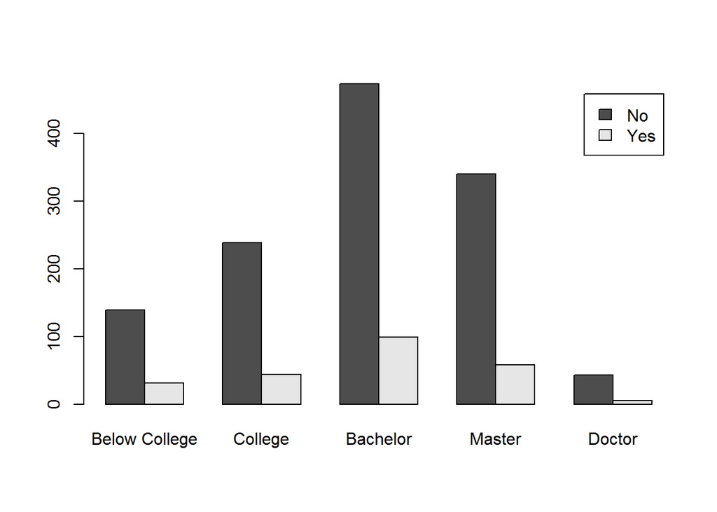

```r
barplot(t1, legend = row.names(t1), beside = TRUE)
```

```r
t2 <- table(casestudy$Attrition, casestudy$environsat)  # Environment satisfaction and Attrition.
t2
```

```
##
##       Low Medium High very High
##   No  212    244  391       386
##   Yes  72     43   62        60
```

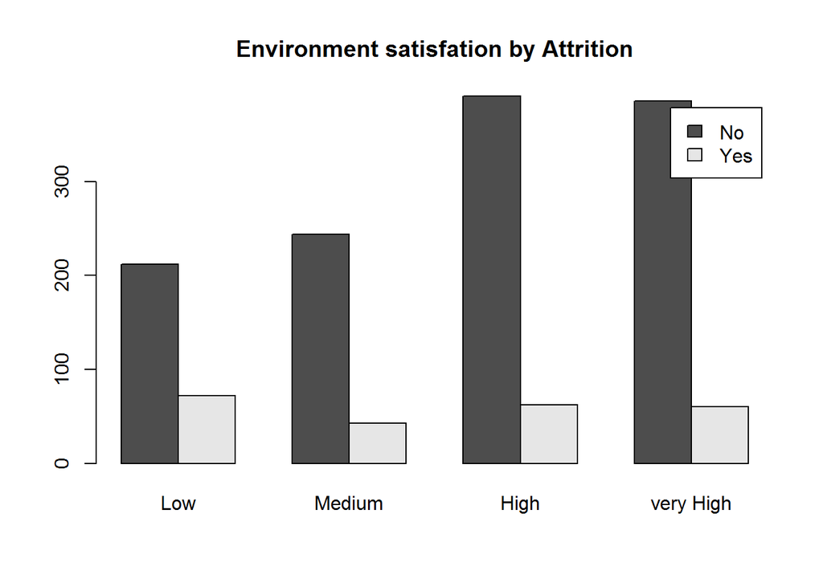

```r
barplot(t2,legend = row.names(t2), beside = TRUE, main = "Environment satisfation by Attrition")
```

```r
# Performance rate and Attrition

t3 <- table(casestudy$Attrition, casestudy$perfrate)
t3
```

```
##
##        Low Good Excellent Outstanding
##   No     0    0      1044         189
##   Yes    0    0       200          37
```

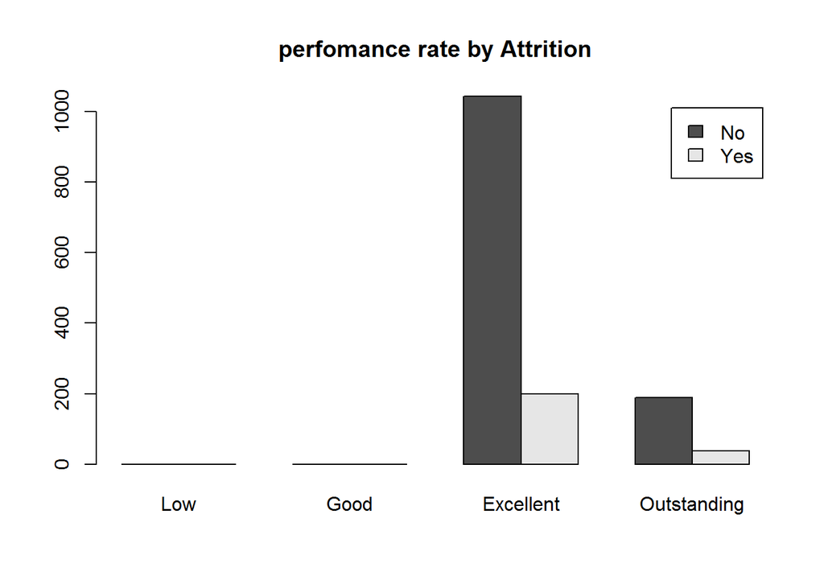

```r
barplot(t3,legend = row.names(t3), beside = TRUE, main = "perfomance rate by Attrition")
```

```r
# Job Satisfaction and Attrition

t4 <- table(casestudy$Attrition, casestudy$jobsat)
t4
```

```
##
##       Low Medium High very High
##   No  223    234  369       407
##   Yes  66     46   73        52
```

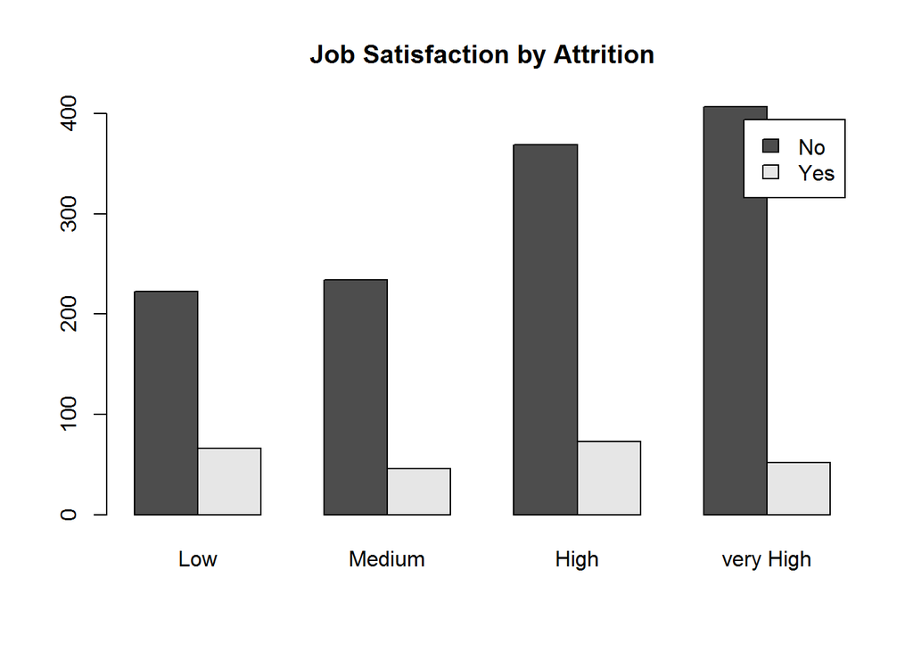

```r
barplot(t4,legend = row.names(t4), beside = TRUE, main = "Job Satisfaction by Attrition")
```

```r
# Job involvement by Attrition

t5 <- table(casestudy$Attrition, casestudy$jobinv)
t5
```

```
##
##       Low Medium High very High
##   No   55    304  743       131
##   Yes  28     71  125        13
```

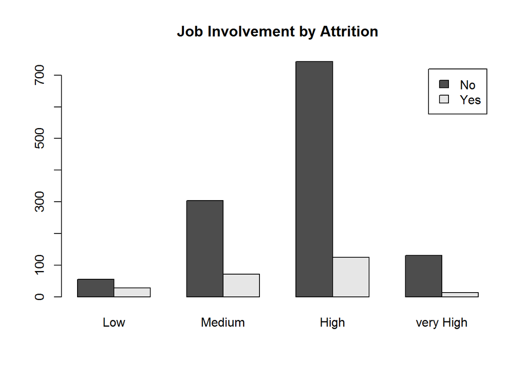

```r
barplot(t5,legend = row.names(t5), beside = TRUE, main = "Job Involvement by Attrition")
```

```r
# relationship satisfaction and Attrition

t6 <- table(casestudy$Attrition, casestudy$relationsat)
t6
```

```
##
##       Low Medium High very High
##   No  219    258  388       368
##   Yes  57     45   71        64
```

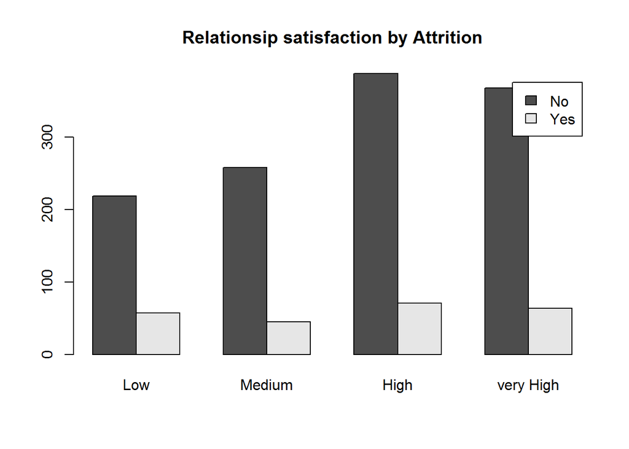

```r
barplot(t6,legend = row.names(t6), beside = TRUE, main = "Relationsip satisfaction by Attrition")
```

```r
# EXAMINING THE EFFECT OF EDUCATION STATUS
# Education status by Performance rating

t7 <- table(casestudy$educ, casestudy$perfrate)
t7
```

```
##
##                 Low Good Excellent Outstanding
##   Below College   0    0       140          30
##   College         0    0       234          48
##   Bachelor        0    0       490          82
##   Master          0    0       341          57
##   Doctor          0    0        39           9
```

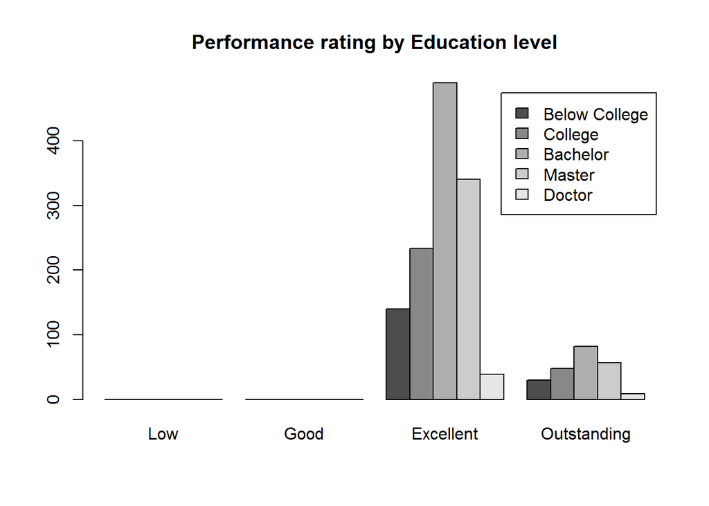

```r
barplot(t7,legend = row.names(t7), beside = TRUE, main = "Performance rating by Education level")
```

```r
#  Job Satisfaction by Education level

t8 <- table(casestudy$educ, casestudy$jobsat)
t8
```

```
##
##                 Low Medium High very High
##   Below College  32     26   56        56
##   College        52     54   83        93
##   Bachelor      118    128  161       165
##   Master         74     67  127       130
##   Doctor         13      5   15        15
```

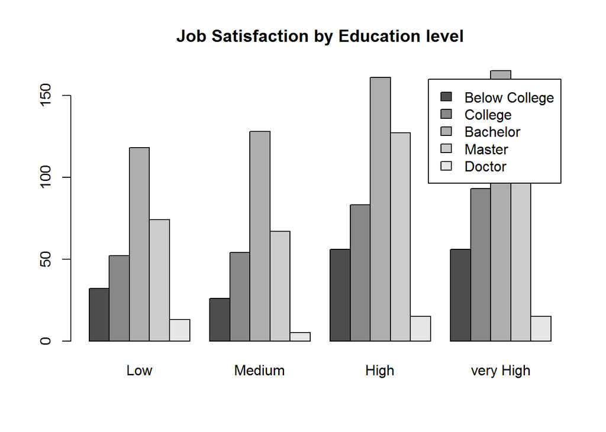

```r
barplot(t8,legend = row.names(t8), beside = TRUE, main = "Job Satisfaction by Education level")
```

```r
knitr::opts_chunk$set(echo = TRUE)
# read in dataset
turnover<-read.csv("E:\\University\\SMU\\Doing the Data Science\\Project2\\CaseStudy2data.csv", header=TRUE,na.strings=c(""))
# find out missing value
sapply(turnover,function(x) sum(is.na(x)))
```

```
##                   ï..Age                Attrition           BusinessTravel
##                        0                        0                        0
##                DailyRate               Department         DistanceFromHome
##                        0                        0                        0
##                Education           EducationField            EmployeeCount
##                        0                        0                        0
##           EmployeeNumber  EnvironmentSatisfaction                   Gender
##                        0                        0                        0
##               HourlyRate           JobInvolvement                 JobLevel
##                        0                        0                        0
##                  JobRole          JobSatisfaction            MaritalStatus
##                        0                        0                        0
##            MonthlyIncome              MonthlyRate       NumCompaniesWorked
##                        0                        0                        0
##                   Over18                 OverTime        PercentSalaryHike
##                        0                        0                        0
##        PerformanceRating RelationshipSatisfaction            StandardHours
##                        0                        0                        0
##         StockOptionLevel        TotalWorkingYears    TrainingTimesLastYear
##                        0                        0                        0
##          WorkLifeBalance           YearsAtCompany       YearsInCurrentRole
##                        0                        0                        0
##  YearsSinceLastPromotion     YearsWithCurrManager
##                        0                        0
```

```r
# no missing values, but first column name looks odd.
# find Column name "Age"
require(dplyr)
turnover1 = rename(turnover, Age = 'ï..Age')
head(turnover1)
```

```
##   Age Attrition    BusinessTravel DailyRate             Department
## 1  41       Yes     Travel_Rarely      1102                  Sales
## 2  49        No Travel_Frequently       279 Research & Development
## 3  37       Yes     Travel_Rarely      1373 Research & Development
## 4  33        No Travel_Frequently      1392 Research & Development
## 5  27        No     Travel_Rarely       591 Research & Development
## 6  32        No Travel_Frequently      1005 Research & Development
##   DistanceFromHome Education EducationField EmployeeCount EmployeeNumber
## 1                1         2  Life Sciences             1              1
## 2                8         1  Life Sciences             1              2
## 3                2         2          Other             1              4
## 4                3         4  Life Sciences             1              5
## 5                2         1        Medical             1              7
## 6                2         2  Life Sciences             1              8
##   EnvironmentSatisfaction Gender HourlyRate JobInvolvement JobLevel
```

[output cut: 48 more lines]

```r
# checking all variables before apply analytics
str(turnover1)
```

```
## 'data.frame':    1470 obs. of  35 variables:
##  $ Age                     : int  41 49 37 33 27 32 59 30 38 36 ...
##  $ Attrition               : Factor w/ 2 levels "No","Yes": 2 1 2 1 1 1 1 1 1 1 ...
##  $ BusinessTravel          : Factor w/ 3 levels "Non-Travel","Travel_Frequently",..: 3 2 3 2 3 2 3 3 2 3 ...
##  $ DailyRate               : int  1102 279 1373 1392 591 1005 1324 1358 216 1299 ...
##  $ Department              : Factor w/ 3 levels "Human Resources",..: 3 2 2 2 2 2 2 2 2 2 ...
##  $ DistanceFromHome        : int  1 8 2 3 2 2 3 24 23 27 ...
##  $ Education               : int  2 1 2 4 1 2 3 1 3 3 ...
##  $ EducationField          : Factor w/ 6 levels "Human Resources",..: 2 2 5 2 4 2 4 2 2 4 ...
##  $ EmployeeCount           : int  1 1 1 1 1 1 1 1 1 1 ...
##  $ EmployeeNumber          : int  1 2 4 5 7 8 10 11 12 13 ...
##  $ EnvironmentSatisfaction : int  2 3 4 4 1 4 3 4 4 3 ...
##  $ Gender                  : Factor w/ 2 levels "Female","Male": 1 2 2 1 2 2 1 2 2 2 ...
##  $ HourlyRate              : int  94 61 92 56 40 79 81 67 44 94 ...
##  $ JobInvolvement          : int  3 2 2 3 3 3 4 3 2 3 ...
```

[output cut: 21 more lines]

```r
# remove NAs if any
turnover2 <- na.omit(turnover1)

## extract factor columns and drop variable with single level
which(sapply(turnover2, function(x) { length(unique(x)) }) == 1)
```

```
## EmployeeCount        Over18 StandardHours
##             9            22            27
```

```r
turnover3 <- turnover2[,-c(27,22,9)]

## count levels
sapply(turnover3, nlevels)
```

```
##                      Age                Attrition           BusinessTravel
##                        0                        2                        3
##                DailyRate               Department         DistanceFromHome
##                        0                        3                        0
##                Education           EducationField           EmployeeNumber
##                        0                        6                        0
##  EnvironmentSatisfaction                   Gender               HourlyRate
##                        0                        2                        0
##           JobInvolvement                 JobLevel                  JobRole
##                        0                        0                        9
##          JobSatisfaction            MaritalStatus            MonthlyIncome
##                        0                        3                        0
##              MonthlyRate       NumCompaniesWorked                 OverTime
##                        0                        0                        2
##        PercentSalaryHike        PerformanceRating RelationshipSatisfaction
##                        0                        0                        0
##         StockOptionLevel        TotalWorkingYears    TrainingTimesLastYear
##                        0                        0                        0
##          WorkLifeBalance           YearsAtCompany       YearsInCurrentRole
##                        0                        0                        0
##  YearsSinceLastPromotion     YearsWithCurrManager
##                        0                        0
```

```r
str(turnover3)
```

```
## 'data.frame':    1470 obs. of  32 variables:
##  $ Age                     : int  41 49 37 33 27 32 59 30 38 36 ...
##  $ Attrition               : Factor w/ 2 levels "No","Yes": 2 1 2 1 1 1 1 1 1 1 ...
##  $ BusinessTravel          : Factor w/ 3 levels "Non-Travel","Travel_Frequently",..: 3 2 3 2 3 2 3 3 2 3 ...
##  $ DailyRate               : int  1102 279 1373 1392 591 1005 1324 1358 216 1299 ...
##  $ Department              : Factor w/ 3 levels "Human Resources",..: 3 2 2 2 2 2 2 2 2 2 ...
##  $ DistanceFromHome        : int  1 8 2 3 2 2 3 24 23 27 ...
##  $ Education               : int  2 1 2 4 1 2 3 1 3 3 ...
##  $ EducationField          : Factor w/ 6 levels "Human Resources",..: 2 2 5 2 4 2 4 2 2 4 ...
##  $ EmployeeNumber          : int  1 2 4 5 7 8 10 11 12 13 ...
##  $ EnvironmentSatisfaction : int  2 3 4 4 1 4 3 4 4 3 ...
##  $ Gender                  : Factor w/ 2 levels "Female","Male": 1 2 2 1 2 2 1 2 2 2 ...
##  $ HourlyRate              : int  94 61 92 56 40 79 81 67 44 94 ...
##  $ JobInvolvement          : int  3 2 2 3 3 3 4 3 2 3 ...
##  $ JobLevel                : int  2 2 1 1 1 1 1 1 3 2 ...
```

[output cut: 18 more lines]

```r
# drop varibles that does not make sense for Attrition
turnover4<-turnover3[-match("EmployeeNumber",names(turnover3))]
head(turnover4)
```

```
##   Age Attrition    BusinessTravel DailyRate             Department
## 1  41       Yes     Travel_Rarely      1102                  Sales
## 2  49        No Travel_Frequently       279 Research & Development
## 3  37       Yes     Travel_Rarely      1373 Research & Development
## 4  33        No Travel_Frequently      1392 Research & Development
## 5  27        No     Travel_Rarely       591 Research & Development
## 6  32        No Travel_Frequently      1005 Research & Development
##   DistanceFromHome Education EducationField EnvironmentSatisfaction Gender
## 1                1         2  Life Sciences                       2 Female
## 2                8         1  Life Sciences                       3   Male
## 3                2         2          Other                       4   Male
## 4                3         4  Life Sciences                       4 Female
## 5                2         1        Medical                       1   Male
## 6                2         2  Life Sciences                       4   Male
##   HourlyRate JobInvolvement JobLevel               JobRole JobSatisfaction
```

[output cut: 41 more lines]

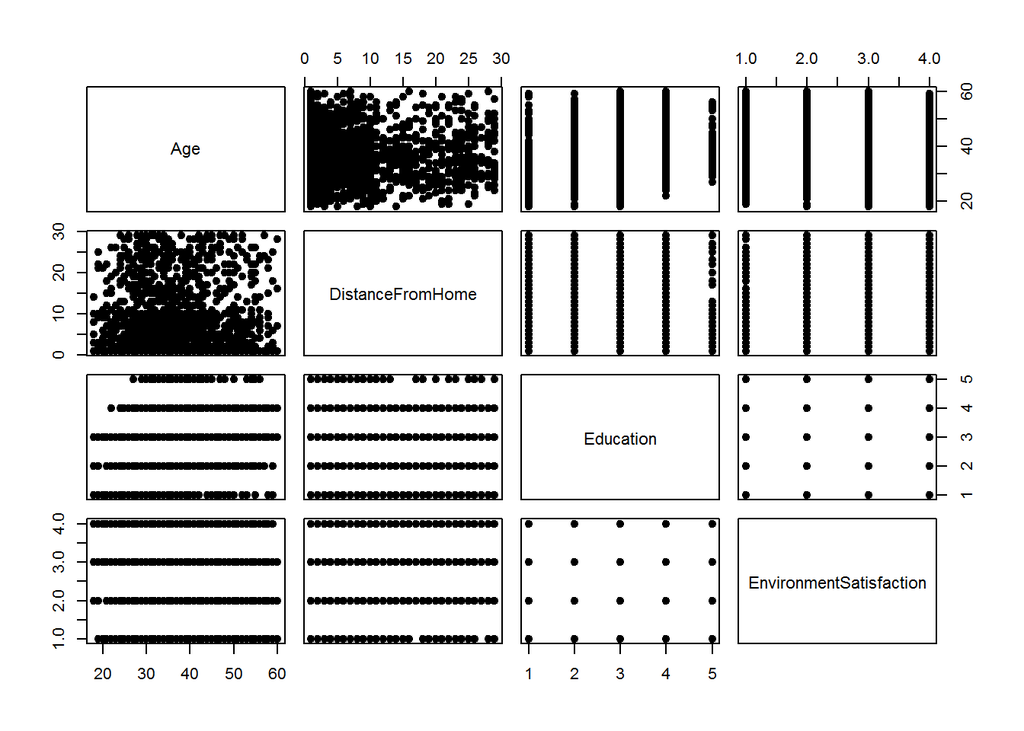

```r
#remove DailyRate, HourlyRate and MonthlyRate, these variables are meaningful for company, not employee
turnover51<- turnover4[, -grep("Rate$", colnames(turnover4))]

# are any varibles correlated?
turnover52 <- turnover51[sapply(turnover51,is.numeric)]
pairs(turnover52[,1:4], pch = 19)
```

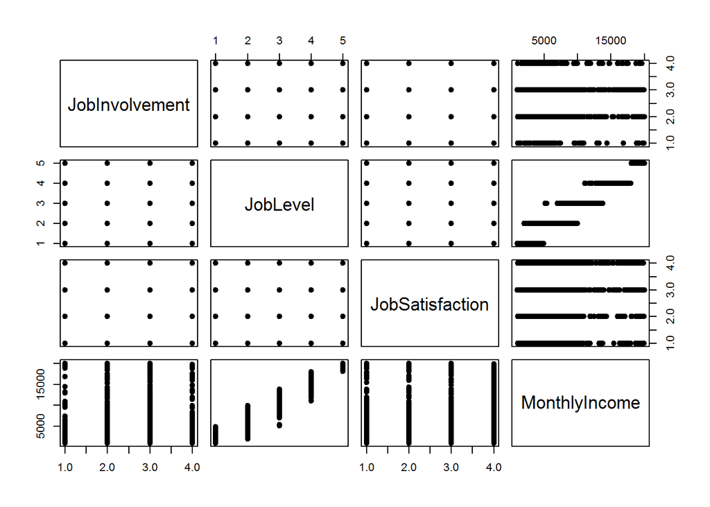

```r
# don't look like anything here
pairs(turnover52[,5:8], pch = 19)
```

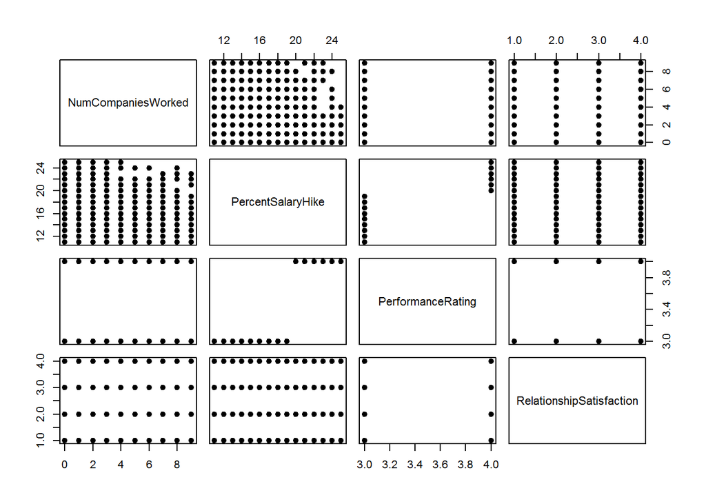

```r
# job level and monthly income have a strong relationship
pairs(turnover52[,9:12], pch = 19)
```

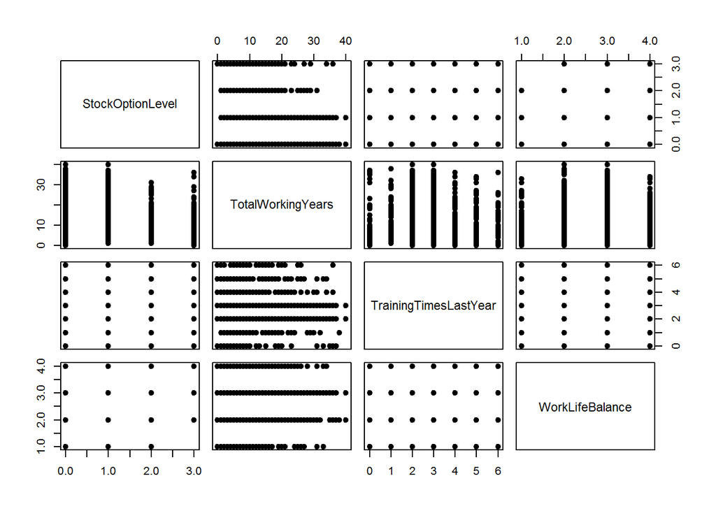

```r
# performance rating and salary hike looks has a tight relationship
pairs(turnover52[,13:16], pch = 19)
```

```r
# nothing here
pairs(turnover52[,17:20], pch = 19)
# we see visible correlation between 4 varibles that starts with Years.
str(turnover52)
```

[output not shown]

```
## 'data.frame':    1470 obs. of  20 variables:
##  $ Age                     : int  41 49 37 33 27 32 59 30 38 36 ...
##  $ DistanceFromHome        : int  1 8 2 3 2 2 3 24 23 27 ...
##  $ Education               : int  2 1 2 4 1 2 3 1 3 3 ...
##  $ EnvironmentSatisfaction : int  2 3 4 4 1 4 3 4 4 3 ...
##  $ JobInvolvement          : int  3 2 2 3 3 3 4 3 2 3 ...
##  $ JobLevel                : int  2 2 1 1 1 1 1 1 3 2 ...
##  $ JobSatisfaction         : int  4 2 3 3 2 4 1 3 3 3 ...
##  $ MonthlyIncome           : int  5993 5130 2090 2909 3468 3068 2670 2693 9526 5237 ...
##  $ NumCompaniesWorked      : int  8 1 6 1 9 0 4 1 0 6 ...
##  $ PercentSalaryHike       : int  11 23 15 11 12 13 20 22 21 13 ...
##  $ PerformanceRating       : int  3 4 3 3 3 3 4 4 4 3 ...
##  $ RelationshipSatisfaction: int  1 4 2 3 4 3 1 2 2 2 ...
##  $ StockOptionLevel        : int  0 1 0 0 1 0 3 1 0 2 ...
##  $ TotalWorkingYears       : int  8 10 7 8 6 8 12 1 10 17 ...
##  $ TrainingTimesLastYear   : int  0 3 3 3 3 2 3 2 2 3 ...
##  $ WorkLifeBalance         : int  1 3 3 3 3 2 2 3 3 2 ...
##  $ YearsAtCompany          : int  6 10 0 8 2 7 1 1 9 7 ...
##  $ YearsInCurrentRole      : int  4 7 0 7 2 7 0 0 7 7 ...
##  $ YearsSinceLastPromotion : int  0 1 0 3 2 3 0 0 1 7 ...
##  $ YearsWithCurrManager    : int  5 7 0 0 2 6 0 0 8 7 ...
```

```r
#finding few of them on scatter plot, attemptt to further verify with cor function
cor(turnover52$Age,turnover52)
```

```
##      Age DistanceFromHome Education EnvironmentSatisfaction JobInvolvement
## [1,]   1      -0.00168612 0.2080337              0.01014643     0.02981996
##       JobLevel JobSatisfaction MonthlyIncome NumCompaniesWorked
## [1,] 0.5096042    -0.004891877     0.4978546          0.2996348
##      PercentSalaryHike PerformanceRating RelationshipSatisfaction
## [1,]       0.003633585       0.001903896               0.05353472
##      StockOptionLevel TotalWorkingYears TrainingTimesLastYear
## [1,]       0.03750971         0.6803805           -0.01962082
##      WorkLifeBalance YearsAtCompany YearsInCurrentRole
## [1,]     -0.02149003      0.3113088          0.2129011
##      YearsSinceLastPromotion YearsWithCurrManager
## [1,]               0.2165134            0.2020886
```

```r
cor(turnover52$PerformanceRating,turnover52)
```

```
##              Age DistanceFromHome   Education EnvironmentSatisfaction
## [1,] 0.001903896       0.02710962 -0.02453879             -0.02954795
##      JobInvolvement    JobLevel JobSatisfaction MonthlyIncome
## [1,]    -0.02907133 -0.02122208     0.002297197   -0.01712014
##      NumCompaniesWorked PercentSalaryHike PerformanceRating
## [1,]        -0.01409487           0.77355                 1
##      RelationshipSatisfaction StockOptionLevel TotalWorkingYears
## [1,]              -0.03135146      0.003506472       0.006743668
##      TrainingTimesLastYear WorkLifeBalance YearsAtCompany
## [1,]           -0.01557888     0.002572361    0.003435126
##      YearsInCurrentRole YearsSinceLastPromotion YearsWithCurrManager
## [1,]         0.03498626              0.01789607           0.02282717
```

```r
cor(turnover52$YearsAtCompany,turnover52)
```

```
##            Age DistanceFromHome Education EnvironmentSatisfaction
## [1,] 0.3113088       0.00950772 0.0691137             0.001457549
##      JobInvolvement  JobLevel JobSatisfaction MonthlyIncome
## [1,]    -0.02135543 0.5347387    -0.003802628     0.5142848
##      NumCompaniesWorked PercentSalaryHike PerformanceRating
## [1,]         -0.1184213       -0.03599126       0.003435126
##      RelationshipSatisfaction StockOptionLevel TotalWorkingYears
## [1,]               0.01936679       0.01505801         0.6281332
##      TrainingTimesLastYear WorkLifeBalance YearsAtCompany
## [1,]           0.003568666      0.01208919              1
##      YearsInCurrentRole YearsSinceLastPromotion YearsWithCurrManager
## [1,]          0.7587537               0.6184089            0.7692124
```